# Computational Skills for Biostatistics I: Lecture 1

Amy Willis, Biostatistics, UW

September 28, 2017

# Welcome!

- Biost 561 is an add-on to Biost 514
- 514 covers basic R commands, 561 covers more advanced R and other programming skills
- As a MS/PhD student in Biostats, you will do some serious programming!
- Good programming practices will help you with research, collaborating, your job search, and your long-term career… whichever path you choose!

# Structure and expectations

- Weekly lectures
- Weekly homeworks
- Weekly office hours: HSB F-657. Tuesday 3:30-5?

# Topics

Subject to change

- 9/28 Lecture 1: Advanced classes, methods, objects, debugging
- 10/5 Lecture 2: Efficient loops, functions
- 10/12 Lecture 3: Pipes
- 10/19 Lecture 4: ggplot
- 10/26 Lecture 5: latex *
- 11/2 Lecture 6: Markdown *
- 11/9 Lecture 7: unix, shell, UW cluster computing *
- 11/16 Lecture 8: version control, git, github, packages
- 11/23 no class; Thanksgiving
- 11/30 Lecture 9: Calling C/C++ in R *
- 12/7 Lecture 10: Python *

* indicates guest lecture by one of your classmates. A great opportunity to learn the latest and greatest!

# Resources

- Available via github
  - Syllabus
  - Slides
  - Source code for slides
  - Examples
  - Homeworks
- Available via github classroom
  - Homework submission
- Available via email
  - Announcements

# Expectations

What you should expect of me

- I will talk slowly (tell me if I’m speaking too fast!)
- I will make your learning a priority
- I will give you timely feedback on your homeworks
- I will treat you as adults, I will treat you with respect
- I will try to make class engaging and fun!

# Expectations

What I will expect of you

- You make attending class a priority
- You submit your best work for homework: your own work, on time
- You engage in classroom discussion and quizzes!
- You learn from the class; you learn to teach yourself programming skills
- You treat me, guest lecturers, and each other with respect

# Assessment

The only assessment in this course is homework.

- 10 or fewer homeworks
- You must submit a good attempt at every homework to receive credit for this course

I won’t record attendance, but if you consistently do not show up you will not receive credit.

# Survey

Everyone is here with different backgrounds in programming and computing. Let’s get statistical!

Class discussion

# Class

There are many different *classes* of objects in R

```r
x <- c(1, 2, 5)
y <- c("a", "b")
z <- as.factor(y)
class(x)
```

```
## [1] "numeric"
```

```r
class(y)
```

```
## [1] "character"
```

```r
class(z)
```

```
## [1] "factor"
```

```r
class(c)
```

```
## [1] "function"
```

Others include `logical` (`TRUE`, `FALSE`), complex numbers…

# Modes

R has different modes. The mode tells the way a variable is stored.

```r
mode(x)
```

```
## [1] "numeric"
```

```r
mode(y)
```

```
## [1] "character"
```

```r
mode(z) # factors are stored as numerics
```

```
## [1] "numeric"
```

```r
mode(c)
```

```
## [1] "function"
```

# Modes

`is.[class]` asks about the class. Normally you will be interested in the class, not the mode.

```r
is.numeric(x)
```

```
## [1] TRUE
```

```r
is.factor(z)
```

```
## [1] TRUE
```

```r
is.numeric(z) # since we asked about the class, not the mode
```

```
## [1] FALSE
```

# Data structures

R can store data in various *objects*

- vector: one-dimensional, all data points have same mode
- matrix: two-dimensional, all data points have same mode
- data frame: two-dimensional, all data points in same column have same mode
- list: one-dimensional, data points can be of any type

# Matrices

Matrices vs data frames: all elements have same mode in matrices

```r
cbind(c(1,2), c("a", "b"))
```

```
##      [,1] [,2]
## [1,] "1"  "a"
## [2,] "2"  "b"
```

```r
data.frame(c(1,2), c("a", "b"))
```

```
##   c.1..2. c..a....b..
## 1       1           a
## 2       2           b
```

```r
data.frame("ID"=c(1,2), "name"=c("a", "b")) # better
```

```
##   ID name
## 1  1    a
## 2  2    b
```

# Matrices

Be very careful with matrix operations!

```r
aa <- matrix(c(1, 2, 3, 5), nrow = 2, byrow = T)
bb <- c(0.5, 2)
aa
```

```
##      [,1] [,2]
## [1,]    1    2
## [2,]    3    5
```

```r
bb
```

```
## [1] 0.5 2.0
```

```r
aa %*% bb # matrix multiplication
```

```
##      [,1]
## [1,]  4.5
## [2,] 11.5
```

```r
aa * bb # careful! pointwise
```

```
##      [,1] [,2]
## [1,]  0.5    1
## [2,]  6.0   10
```

# vectorisation

vectorisation: doing many calculations with a single command

```r
x <- c(0.5, 2, 3, 6)
x^2
```

```
## [1]  0.25  4.00  9.00 36.00
```

```r
y <- c(3, 1, 2, 1)
x^y
```

```
## [1] 0.125 2.000 9.000 6.000
```

```r
z <- rep(NA, 4)
for (i in 1:4) {
  z[i] <- x[i]^y[i]
}
z
```

```
## [1] 0.125 2.000 9.000 6.000
```

Code is easier to read, and usually easier to debug, when vectorised

# recycling

In many tasks, R recycles elements of one input until it has enough to match the other

```r
aa
```

```
##      [,1] [,2]
## [1,]    1    2
## [2,]    3    5
```

```r
bb
```

```
## [1] 0.5 2.0
```

```r
aa + bb # vectors are treated as columns!
```

```
##      [,1] [,2]
## [1,]  1.5  2.5
## [2,]  5.0  7.0
```

```r
cc <- c(1, 2, 3, 4)
aa + cc # the silent killer
```

```
##      [,1] [,2]
## [1,]    2    5
## [2,]    5    9
```

Be careful!

# Speed comparison

Vectorisation can cause major speed-ups, because task is optimised and precompiled in C/Fortran, not interpreted R.

```r
dd <- matrix(rnorm(1e6), nrow = 1000)
cor(dd)

ee <- matrix(NA, 1000, 1000)
for (i in 1:1000) {
  for (j in 1:1000) {
    ee[i, j] <- cor(ee[, i], ee[, j])
  }
}
```

Speed up factor of vectorisation: 36!

# Lists

Lists store information of many different types

```r
amy <- list(office.num = 657, pets = TRUE,
            pets.names = c("Princess Jaws", "Friendly", "Mohawk",
                           "Canada", "USA", "Regina George"),
            is.cat = c(TRUE, rep(FALSE, 5)))
amy
```

```
## $office.num
## [1] 657
##
## $pets
## [1] TRUE
##
## $pets.names
## [1] "Princess Jaws" "Friendly"      "Mohawk"        "Canada"
## [5] "USA"           "Regina George"
##
## $is.cat
## [1]  TRUE FALSE FALSE FALSE FALSE FALSE
```

# Lists

Names are optional, but recommended!

Double square brackets pull out individual elements. Single square brackets pull out subsets of the list. I recommend using names wherever possible!

```r
amy[[3]] # subset third element
```

```
## [1] "Princess Jaws" "Friendly"      "Mohawk"        "Canada"
## [5] "USA"           "Regina George"
```

```r
amy[3] # third element -- a list!
```

```
## $pets.names
## [1] "Princess Jaws" "Friendly"      "Mohawk"        "Canada"
## [5] "USA"           "Regina George"
```

```r
amy[2:3] # second and third elements -- a list!
```

```
## $pets
## [1] TRUE
##
## $pets.names
## [1] "Princess Jaws" "Friendly"      "Mohawk"        "Canada"
## [5] "USA"           "Regina George"
```

```r
amy$office
```

```
## [1] 657
```

# Generic functions

The same function can apply to objects of different classes. How does R know what to do?

```r
c(class(log), class(trees))
```

```
## [1] "function"   "data.frame"
```

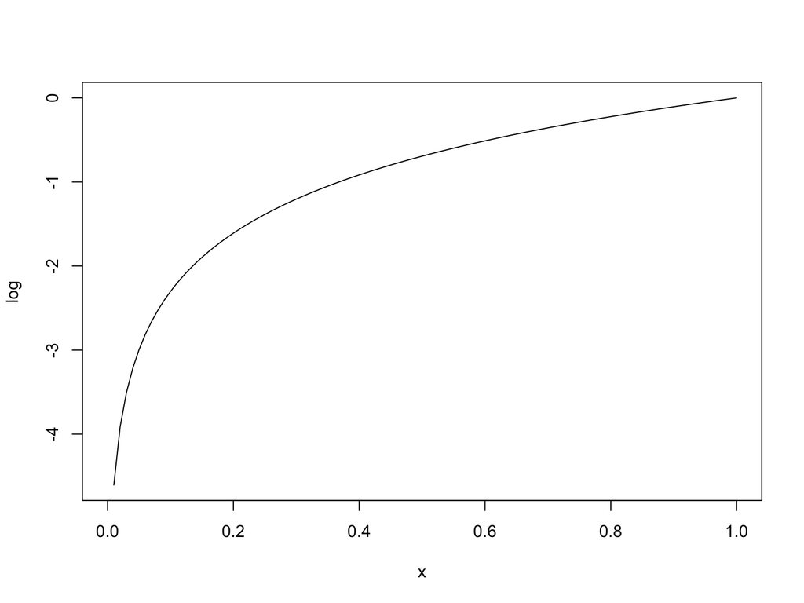

```r
plot(log)
```

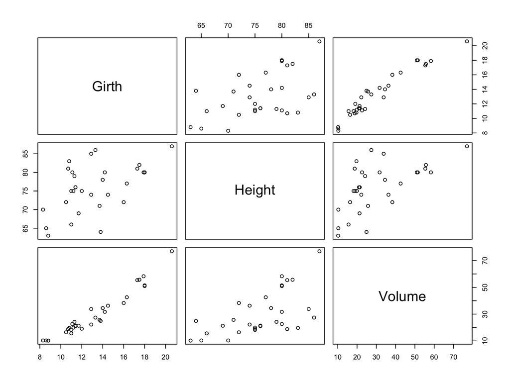

```r
plot(trees)
```

# Generic functions

`plot` is a *generic* function. Generic functions don’t do anything themselves – they call *methods*, which are tailored to the class.

```r
plot
```

```
## function (x, y, ...)
## UseMethod("plot")
## <bytecode: 0x7fcb87285b50>
## <environment: namespace:graphics>
```

```r
methods("plot") # lists all types that R knows how to plot
```

```
##  [1] plot.acf*           plot.data.frame*    plot.decomposed.ts*
##  [4] plot.default        plot.dendrogram*    plot.density*
##  [7] plot.ecdf           plot.factor*        plot.formula*
## [10] plot.function       plot.hclust*        plot.histogram*
## [13] plot.HoltWinters*   plot.isoreg*        plot.lm*
## [16] plot.medpolish*     plot.mlm*           plot.ppr*
## [19] plot.prcomp*        plot.princomp*      plot.profile.nls*
## [22] plot.raster*        plot.spec*          plot.stepfun
## [25] plot.stl*           plot.table*         plot.ts
## [28] plot.tskernel*      plot.TukeyHSD*
## see '?methods' for accessing help and source code
```

# Generic functions

To find the functions that apply to a class

```r
methods(class = "lm")
```

```
##  [1] add1           alias          anova          case.names
##  [5] coerce         confint        cooks.distance deviance
##  [9] dfbeta         dfbetas        drop1          dummy.coef
## [13] effects        extractAIC     family         formula
## [17] hatvalues      influence      initialize     kappa
## [21] labels         logLik         model.frame    model.matrix
## [25] nobs           plot           predict        print
## [29] proj           qr             residuals      rstandard
## [33] rstudent       show           simulate       slotsFromS3
## [37] summary        variable.names vcov
## see '?methods' for accessing help and source code
```

# Generic functions

To see the code for a generic function, type `[function].[class]`

```r
dimnames.data.frame
```

```
## function (x)
## list(row.names(x), names(x))
## <bytecode: 0x7fcb88414fc8>
## <environment: namespace:base>
```

# Help

There are many ways to get help with using functions or debugging code

1. The internet

[picture]

# Help

2. `?fn` shows the documentation for `fn`… if it exists!

[picture]

# Help

3. `help.search("topic")` searches help pages for “topic”

[picture]

# Examples

The documentation pages often show examples (`example(plot)`) and have demos (`demo(plotmath)`). `vignette()` opens longer worked examples that are great for playing with new packages.

# Keep in mind

- The user of a function assumes responsibility for giving arguments in the correct form
- arguments are ordered
  - Unnamed arguments are allocated as first arguments
  - Named arguments can be anywhere in ordering
- Not supplied arguments assume default value
  - Not supplying arguments without a default gives an error message

Don’t get bogged down in reading *all* the documentation – experiment and learn from your mistakes instead!

# Debugging

1. Stare at it until you identify the problem a.k.a. psychic debugging
2. Breakdown the components until you find the problem (bisection method converges linearly!)
3. `traceback()` – covered later in the course

# Homework 1 and next week